# Reproducible and interactive reporting in R

March 01, 2016

## Overview

- OpenEarth
- Ecological monitoring Marine Projects
- Interactive data exploration
- Transparant and reproducible data products

## OpenEarth data management

- Data, Models, Tools
- Generic workflow and conventions
  - Version control of data and tools
  - Traceable and reproducible
  - Use available open technical and semantic standards
  - Open Source software

[figure not shown]

[figure not shown]

## Ecological monitoring Marine Projects

- Ecological monitoring
  - Licencing process e.g. wind parks
  - diverse data
  - [make data available](http://marineprojects.openearth.nl/)
  - for multiple use
  - all use same version

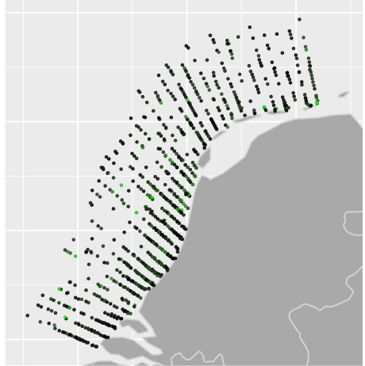

## Interactive documents

## Rshiny - interactivity

- Model as a service
- Web application
  - [North Sea Waterbase data](http://tl-284.xtr.deltares.nl:3838/deltares/Noordzee/) (at Deltares test server, only from within Deltares intranet)
  - [same at Rstudio Shinyapps service](https://gammarus.shinyapps.io/ShinyWaterbaseNoordzee)
- Html document
  - [ShWoZ Bird heatmaps](https://gammarus.shinyapps.io/Interactive_gridding/)

## Rshiny - how to go about

- Design and code
  - UI and Server script (named UI.r and Server.r)
    - can be combined in one script.
    - RStudio: File/New Project../ new folder / Shiny web application
- Run app
  - Within Rstudio
    - Rstudio contains ShinyServer
  - Deploy app via Rstudio [Shinyapps](http://www.shinyapps.io/)
  - Deploy app via locally installed [ShinyServer](http://tl-284.xtr.deltares.nl:3838/)

## Reproducible reporting

## Principle

- Transparent work flow
- From data source to final product
- Optimal when
  - Centralized source data
  - Version controlled scripts
  - Keep scripts and report together
    - Rmarkdown (R, basic Python, more)
    - [Jupyter](https://www.continuum.io/blog/developer/jupyter-and-conda-r?mc_cid=c91ccee4a5&mc_eid=3a45b30e21) (Python, R, Matlab, more) or [here](https://irkernel.github.io/installation/)

## Rmarkdown

- A Markdown-formatted document should be publishable as-is, as plain text, without looking like it’s been marked up with tags or formatting instructions. – John Gruber
- comes as R package (runs from every IDE or from console)
- R code + text/MD/html –> markdown (MD) –> pdf, html, word
- html can be combined with interactivity (Shiny)

## What does Rmarkdown do?

Code chunks

```{r}  
plot(cars)  
```

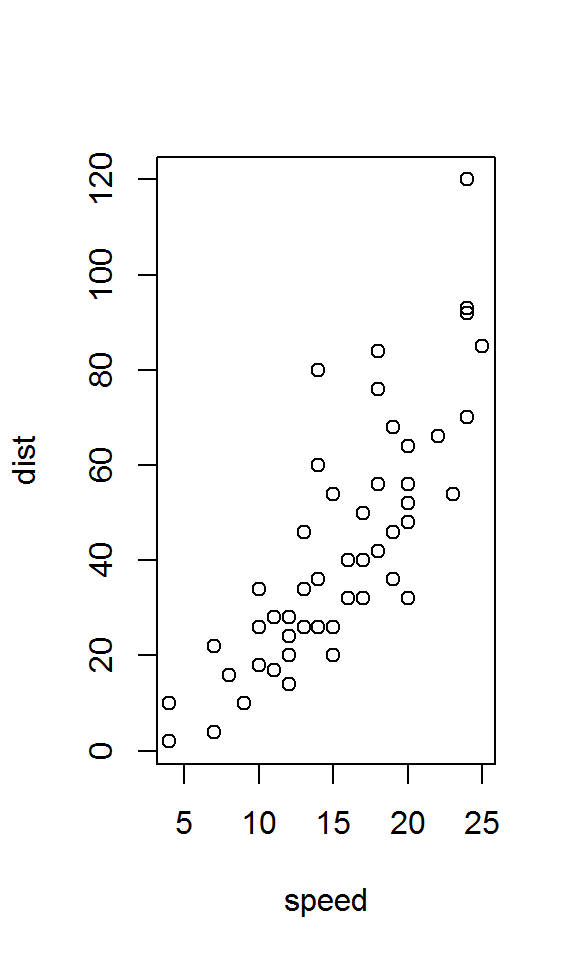

## Also works with Python

```{python}  
x = 1  
if x == 1:  
# indented four spaces  
print "x is 1."  
```

generates:

```python
x = 1
if x == 1:
    # indented four spaces
    print "x is 1."
```

```
## x is 1.
```

But graphics are apparently not (yet) supported..

## In-line code in markdown document

Or run inline code to calculate that the average speed = 15.4 .

in Rmarkdown:

Or run inline code to calculate that the average speed = `r_ mean(cars$speed) ` .

## Styling and formatting of Rmarkdown reports

- [R markdown](http://rmarkdown.rstudio.com/)
- [Cheatsheets](http://www.rstudio.com/wp-content/uploads/2015/02/rmarkdown-cheatsheet.pdf)
- use css (Custom Style Sheet)

## Accessing data

- Connecting to a database
- Connecting to a service (WFS)

[figure not shown]

## Gridded data products

- Heat maps
- Data interpolation
- Export to NetCDF file format

## Practical

- Start Rshiny document
- Start Rmarkdown document
- Use open data set

## Connect to WFS

Read GeoJSON WFS and plot in leaflet map The data that are used here are pelagic fish data from the MEP-NSW ecological monitoring. Look at the url: only the first 50 records are read here.

```r
url <- "http://marineprojects.openearth.nl/geoserver/mep-nsw/ows?service=WFS&version=1.0.0&request=GetFeature&typeName=mep-nsw:mep-nsw_pvis&maxFeatures=50&outputFormat=json"
```

## Connect to WFS

```r
jsonResult <- GET(url)
leaflet() %>% setView(lat = 52.5, lng = 4.5, zoom = 9) %>% addTiles(group = "OSM (default)") %>%
    addGeoJSON(content(jsonResult), layerId = "Monster.identificatie")
```

[output not shown]

## Extra material

- Possibility to convert R markdown into [slidify](http://slidify.github.io/dcmeetup/#8) presentations